# CSP-571 Project - Predicting Mushroom Edibility

Liwei He

# 1. Project Goal

Link to the dataset:

Biology  
Mushrooms: https://visualization.group/data/mushroom/

I’m using the [UCI Secondary Mushroom Dataset](https://archive.ics.uci.edu/dataset/848/secondary+mushroom+dataset) to predict whether a simulated mushroom record is edible or poisonous.

I built and compared three models: logistic regression, a decision tree, and a random forest.

# 2. Data Reading and Cleaning

The raw file is semicolon-delimited and contains one target variable and 20 predictors.

```r
RUN_QC <- FALSE
RUN_PLOTS <- FALSE
source("code/01_eda.R")
```

```
##
## --- CLEANING SUMMARY ---
##                            item value
##            Rows before cleaning 61069
##    Exact duplicate rows removed   146
##             Rows after cleaning 60923
##        Remaining missing values     0
##  Conflicting predictor patterns     0
##
## EDA preparation completed successfully.
## Use names(eda_plots) to list the available plot objects.
```

```r
data_summary <- data.frame(
  Item = c(
    "Raw rows",
    "Columns",
    "Numerical predictors",
    "Categorical predictors"
  ),
  Value = c(
    nrow(mushrooms),
    ncol(mushrooms),
    length(numeric_variables),
    length(categorical_variables)
  )
)

knitr::kable(data_summary, caption = "Data overview")
```

Data overview

| Item | Value |
| --- | --- |
| Raw rows | 61069 |
| Columns | 21 |
| Numerical predictors | 3 |
| Categorical predictors | 17 |

9 categorical predictors have missing values, some quite heavily. Rather than dropping those rows, I recoded missing entries as an explicit `unknown` level, and removed 146 exact duplicate rows before splitting the data.

```r
knitr::kable(
  cleaning_summary,
  col.names = c("Cleaning check", "Value"),
  caption = "Cleaning results"
)
```

Cleaning results

| Cleaning check | Value |
| --- | --- |
| Rows before cleaning | 61069 |
| Exact duplicate rows removed | 146 |
| Rows after cleaning | 60923 |
| Remaining missing values | 0 |
| Conflicting predictor patterns | 0 |

The final modeling dataset contains 60,923 rows, no missing values, and no exact duplicates.

# 3. Exploratory Data Analysis

## Class distribution

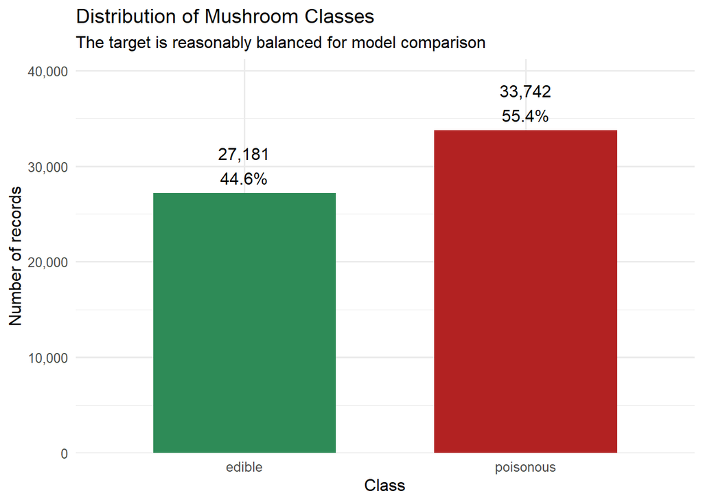

```r
eda_plots$class_distribution
```

The classes are close to balanced - 44.6% edible, 55.4% poisonous - so accuracy is a reasonable metric here. I also track poisonous-class recall, since calling a poisonous mushroom “edible” is the costlier mistake.

## Missing values

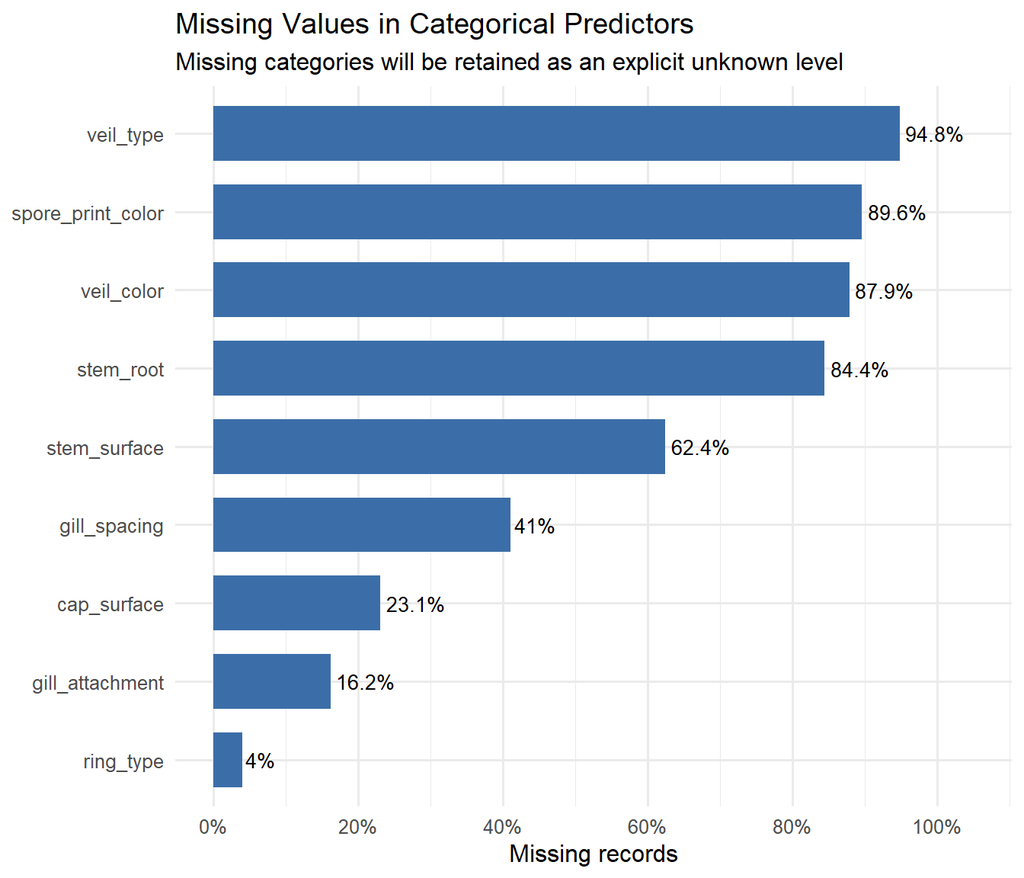

```r
eda_plots$missing_values
```

A handful of variables are missing more than 80% of their values, which ruled out dropping incomplete rows. I kept them and coded missing entries as their own `unknown` level - if missingness itself correlates with edibility, the model can use that signal instead of losing it.

## Numerical predictors

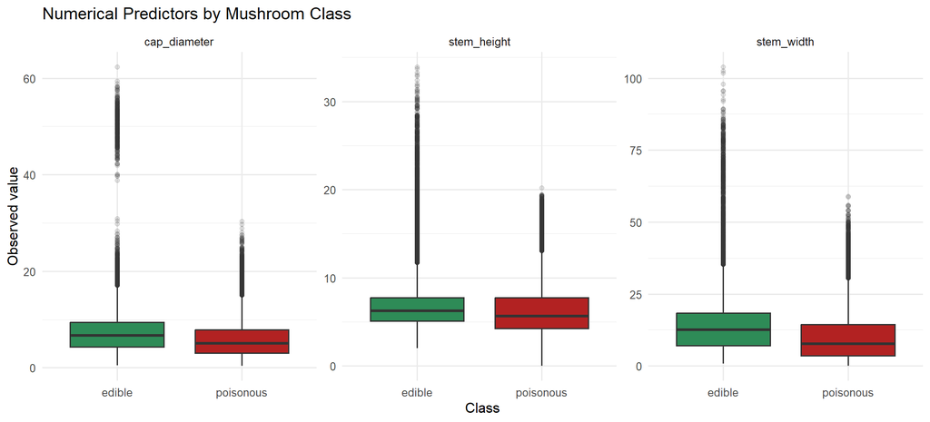

```r
eda_plots$numeric_boxplots
```

Edible mushrooms tend to run a bit larger - bigger cap diameter, taller and wider stems, though all three measurements have long right tails. I left those outliers in; they’re part of the simulated data as generated.

## Selected categorical predictors

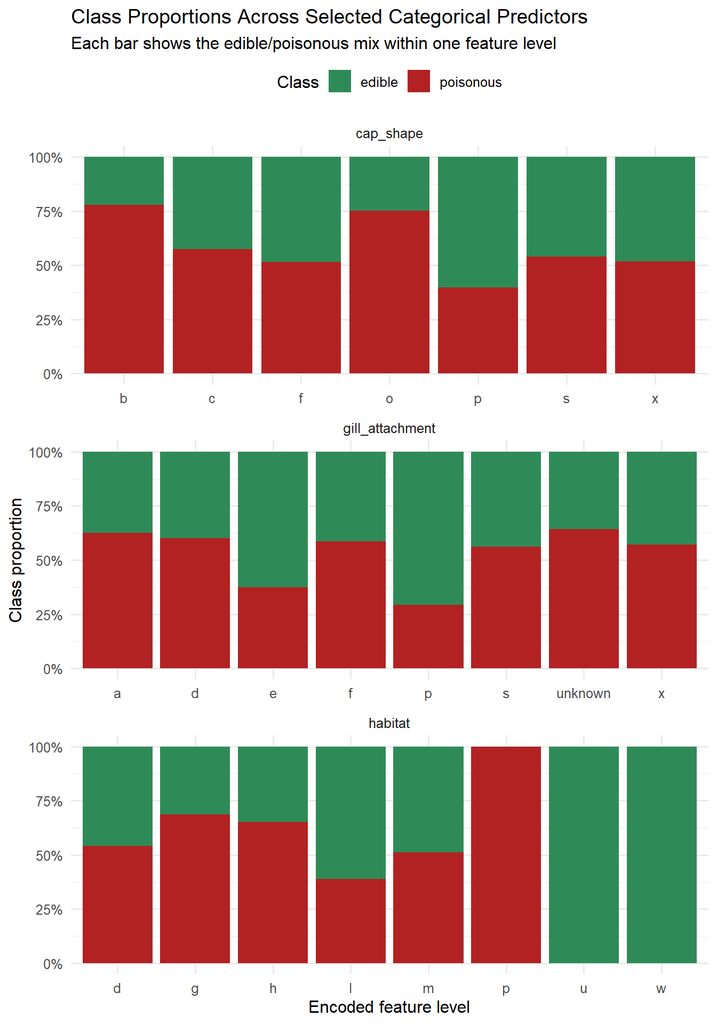

```r
eda_plots$categorical_class_proportions
```

I selected `cap_shape`, `gill_attachment`, and `habitat` for this plot - together they cover cap morphology, gill structure, and growing environment, and their levels show visibly different class proportions. A few habitat categories are entirely one class, but those are also the smallest groups. Most common levels still contain a mix of both classes, which is the point of combining several predictors in a model.

# 4. Train/Test Split

I use `set.seed(571)` and an 80/20 stratified split. All three models are evaluated on the same held-out test set.

```r
RUN_QC <- FALSE
RUN_PLOTS <- FALSE
RUN_MODEL_PLOTS <- FALSE
source("code/02_modeling.R")
```

```r
knitr::kable(split_summary, caption = "Stratified data split")
```

Stratified data split

| dataset | rows | edible_percent | poisonous_percent |
| --- | --- | --- | --- |
| Full cleaned data | 60923 | 44.62 | 55.38 |
| Training set | 48737 | 44.61 | 55.39 |
| Test set | 12186 | 44.62 | 55.38 |

The class proportions are nearly identical across the training and test sets.

# 5. Logistic Regression

The logistic model provides a linear baseline. Numerical predictors are standardized using training-set statistics only.

```r
knitr::kable(
  as.data.frame.matrix(logistic_results$confusion_matrix),
  caption = "Logistic regression confusion matrix"
)
```

Logistic regression confusion matrix

|  | edible | poisonous |
| --- | --- | --- |
| edible | 4646 | 791 |
| poisonous | 848 | 5901 |

Logistic regression is the weakest of the three, with 848 dangerous false negatives. R also warns that some fitted probabilities are numerically 0 or 1, a sign the classes are close to perfectly separable on some combination of predictors - logistic regression just isn’t flexible enough to find that boundary. I use it mainly as a baseline rather than digging into individual coefficients.

# 6. Decision Tree

```r
knitr::kable(
  as.data.frame.matrix(tree_results$confusion_matrix),
  caption = "Decision tree confusion matrix"
)
```

Decision tree confusion matrix

|  | edible | poisonous |
| --- | --- | --- |
| edible | 5364 | 73 |
| poisonous | 60 | 6689 |

The full tree does much better - 98.91% test accuracy, 60 dangerous false negatives. It’s too large to plot legibly, so the figure below is a pruned version showing the top few splits; the reported numbers still come from the full tree.

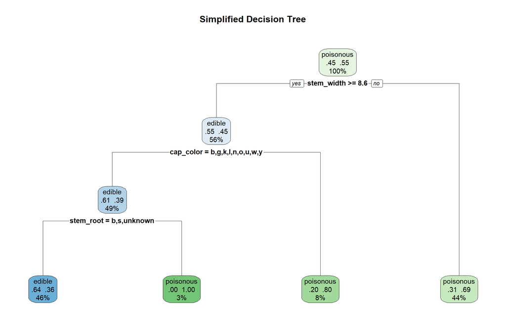

```r
display_candidates <- tree_model$cptable[
  tree_model$cptable[, "nsplit"] <= 6,
  ,
  drop = FALSE
]

display_cp <- display_candidates[nrow(display_candidates), "CP"]
display_tree <- rpart::prune(tree_model, cp = display_cp)

rpart.plot::rpart.plot(
  display_tree,
  type = 2,
  extra = 104,
  fallen.leaves = TRUE,
  tweak = 0.9,
  main = "Simplified Decision Tree"
)
```

Stem width is the first split, then cap color, then stem root. It’s a clean illustration of how a tree turns classification into readable if/then rules - though these specific thresholds are fit to one simulated dataset, not mycological fact.

# 7. Random Forest

The random forest combines 300 trees and provides an out-of-bag error estimate.

```r
knitr::kable(
  as.data.frame.matrix(random_forest_results$confusion_matrix),
  caption = "Random forest confusion matrix"
)
```

Random forest confusion matrix

|  | edible | poisonous |
| --- | --- | --- |
| edible | 5437 | 0 |
| poisonous | 0 | 6749 |

```r
oob_result <- data.frame(
  Measure = "OOB error",
  Value = round(as.numeric(random_forest_oob_error), 6)
)

knitr::kable(oob_result, caption = "Random forest OOB result")
```

Random forest OOB result

| Measure | Value |
| --- | --- |
| OOB error | 0 |

The random forest gets every test record right, with zero OOB error. This matches the dataset’s original paper, so it’s not a bug on my end - the simulated data is just that separable. It’s a strong result on this benchmark, not proof the model would generalize to a real, unseen species.

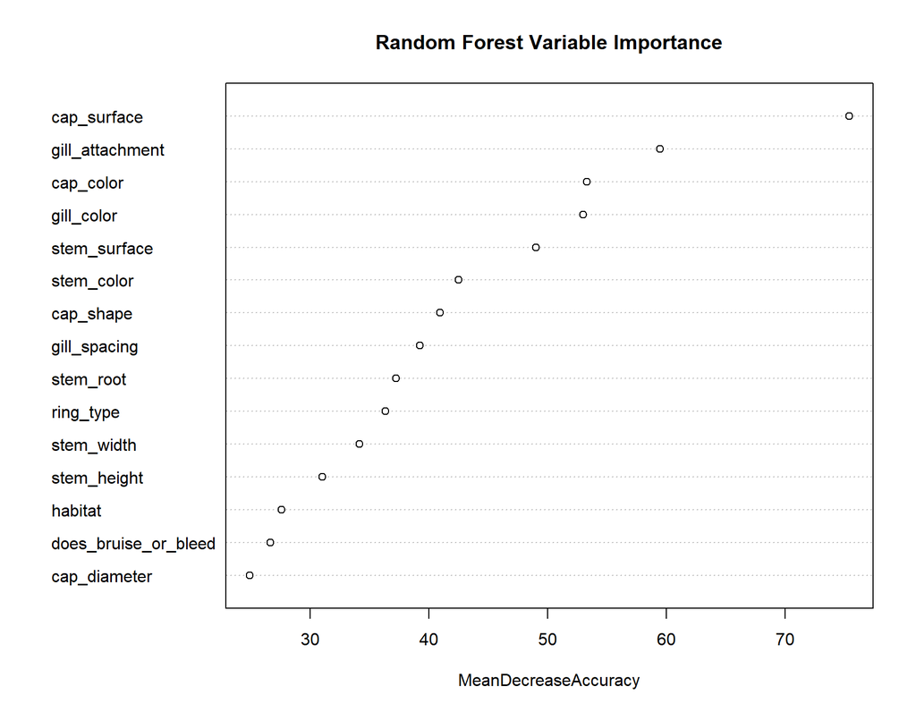

```r
randomForest::varImpPlot(
  random_forest_model,
  type = 1,
  n.var = 15,
  main = "Random Forest Variable Importance"
)
```

```r
correlation_check <- data.frame(
  Comparison = c(
    "stem_width vs. cap_diameter",
    "stem_width vs. stem_height"
  ),
  Pearson = c(
    cor(mushrooms_clean$stem_width, mushrooms_clean$cap_diameter, method = "pearson"),
    cor(mushrooms_clean$stem_width, mushrooms_clean$stem_height, method = "pearson")
  ),
  Spearman = c(
    cor(mushrooms_clean$stem_width, mushrooms_clean$cap_diameter, method = "spearman"),
    cor(mushrooms_clean$stem_width, mushrooms_clean$stem_height, method = "spearman")
  )
)

knitr::kable(
  correlation_check,
  digits = 3,
  caption = "Correlation check for numerical size predictors"
)
```

Correlation check for numerical size predictors

| Comparison | Pearson | Spearman |
| --- | --- | --- |
| stem_width vs. cap_diameter | 0.695 | 0.863 |
| stem_width vs. stem_height | 0.433 | 0.498 |

`cap_surface`, `gill_attachment`, `cap_color`, and `gill_color` top the random forest’s permutation-importance ranking. `stem_width` - the first split in the simplified tree - ranks around 11th. That’s not a contradiction: a single tree picks the locally best one-step split, while permutation importance measures the accuracy drop from shuffling a variable across the whole forest. The correlation check shows why: `stem_width` overlaps heavily with `cap_diameter` (r = 0.695, Spearman = 0.863), more than with `stem_height`. Once `cap_diameter` is available, shuffling `stem_width` doesn’t cost the forest much - it can recover similar information elsewhere. The ranking reflects each variable’s marginal contribution within this forest, not a causal claim about what makes a mushroom poisonous.

# 8. Model Comparison and Conclusion

```r
comparison_table <- model_comparison

percentage_columns <- c(
  "Accuracy",
  "Poisonous_Recall",
  "Specificity",
  "Precision",
  "F1"
)

comparison_table[percentage_columns] <- lapply(
  comparison_table[percentage_columns],
  scales::percent,
  accuracy = 0.01
)

knitr::kable(
  comparison_table,
  caption = "Held-out test-set model comparison"
)
```

Held-out test-set model comparison

| Model | Accuracy | Poisonous_Recall | Specificity | Precision | F1 | AUC | Dangerous_False_Negatives |
| --- | --- | --- | --- | --- | --- | --- | --- |
| Logistic Regression | 86.55% | 87.44% | 85.45% | 88.18% | 87.81% | 0.9412 | 848 |
| Decision Tree | 98.91% | 99.11% | 98.66% | 98.92% | 99.02% | 0.9952 | 60 |
| Random Forest | 100.00% | 100.00% | 100.00% | 100.00% | 100.00% | 1.0000 | 0 |

Random forest wins outright - perfect metrics, zero dangerous false negatives. The decision tree is close behind at 98.91% accuracy and has one real advantage: you can explain the rule to someone. Logistic regression trails both by a wide margin, which suggests the edible/poisonous boundary here isn’t linear. There’s enough interaction between stem dimensions, color and surface texture, that a straight-line model can’t capture it.

I will go with the random forest: the cost of a false negative is too high to trade away for interpretability. The decision tree as the easy-to-explain version, since a 1-2% accuracy gap is okay for something you can actually walk someone through.

One caveat on the perfect random forest score: all 61,069 records come from the same simulation process built on only 173 real species, so a random train/test split isn’t really testing on an unseen species - it’s closer to testing on a held-out sample from the same distribution. A species-aware split would be a tougher, more realistic test. I didn’t have time to build that here, but it’s the first thing I’d try next, along with checking how much accuracy holds up using just the top 3-4 features.

**AI Assistance Note**

The explanation of why `stem_width` was the top split in the pruned decision tree but ranked around 11th in the random forest’s permutation importance came out of a discussion with Claude (Sonnet 5).